# reticulate FotD

```r
knitr::opts_chunk$set(echo = TRUE)
library(tidyverse)
library(kableExtra)
library(reticulate)
```

# 1 Reticulate

you can use any conda environment to run python code in R.

```r
reticulate::conda_list(conda = "auto") %>%
  kbl() %>%
  kable_paper("hover", full_width = F)
```

| name | python |
| --- | --- |
| r-miniconda | /home/ubuntu/.local/share/r-miniconda/bin/python |
| r-reticulate | /home/ubuntu/.local/share/r-miniconda/envs/r-reticulate/bin/python |
| anaconda3 | /home/ubuntu/data/anaconda3/bin/python |
| myRenv3_4 | /home/ubuntu/data/anaconda3/envs/myRenv3_4/bin/python |
| p27 | /home/ubuntu/data/anaconda3/envs/p27/bin/python |
| r_3.4.0 | /home/ubuntu/data/anaconda3/envs/r_3.4.0/bin/python |

```r
py_config()
```

```
## python:         /home/ubuntu/.local/share/r-miniconda/envs/r-reticulate/bin/python
## libpython:      /home/ubuntu/.local/share/r-miniconda/envs/r-reticulate/lib/libpython3.6m.so
## pythonhome:     /home/ubuntu/.local/share/r-miniconda/envs/r-reticulate:/home/ubuntu/.local/share/r-miniconda/envs/r-reticulate
## version:        3.6.13 | packaged by conda-forge | (default, Sep 23 2021, 07:56:31)  [GCC 9.4.0]
## numpy:          /home/ubuntu/.local/share/r-miniconda/envs/r-reticulate/lib/python3.6/site-packages/numpy
## numpy_version:  1.19.5
##
## NOTE: Python version was forced by RETICULATE_PYTHON
```

# 2 Radius Neighbors Classifier

Using epigenomic markers near insertion sites in CART theraphy to alucidate which sites might predict treatment outcome.

```r
df <- readRDS(file.path(.data_d,'tsne-df.rds'))
head(df) %>%
  kbl() %>%
  kable_paper() %>%
  scroll_box(width = "80%", height = "200px")
```

X

Y

seqnames

start

end

width

strand

refGenome

reads

patient

GTSP

cellType

timePoint

timePointDays

timePointMonths

posid

estAbund

relAbund

inFeature

nearestFeature

nearestFeatureStrand

inFeatureExon

inFeatureSameOrt

nearestFeatureDist

nearestOncoFeature

nearestOncoFeatureDist

nearestOncoFeatureStrand

nearestlymphomaFeature

nearestlymphomaFeatureDist

nearestlymphomaFeatureStrand

GTPSposID

Response_class

6.4449358

9.104940

chr1

10296596

10296596

1

hg38

1

p03712-03

GTSP0567

Tcells:CAR+CD8-

D14

14

0

chr1-10296596

1

0.0131165

TRUE

KIF1B

TRUE

FALSE

0

PIK3CD

567670

LCK

-21954641

GTSP0567chr1-10296596

CR/PRtd

6.4449358

9.104940

chr1

10296596

10296596

1

hg38

1

p03712-03

GTSP0567

Tcells:CAR+CD8-

D14

14

0

chr1-10296596

1

0.0131165

TRUE

KIF1B

TRUE

FALSE

0

PIK3CD

567670

LCK

-21954641

GTSP0567chr1-10296596

CR/PRtd

-9.2297657

-5.419996

chr1

103204467

103204467

1

hg38

1

p03712-03

GTSP0567

Tcells:CAR+CD8-

D14

14

0

chr1-103204467

1

0.0131165

FALSE

COL11A1

FALSE

TRUE

-95970

COL11A1

-95970

STIL

-55890319

GTSP0567chr1-103204467

CR/PRtd

-9.2297657

-5.419996

chr1

103204467

103204467

1

hg38

1

p03712-03

GTSP0567

Tcells:CAR+CD8-

D14

14

0

chr1-103204467

1

0.0131165

FALSE

COL11A1

FALSE

TRUE

-95970

COL11A1

-95970

STIL

-55890319

GTSP0567chr1-103204467

CR/PRtd

-0.2126238

-1.828890

chr1

10465970

10465970

1

hg38

168

p03712-03

GTSP0567

Tcells:CAR+CD8-

D14

14

0

chr1-10465970

1

0.0131165

TRUE

DFFA

FALSE

TRUE

0

MTOR

640559

LCK

-21785267

GTSP0567chr1-10465970

CR/PRtd

-0.2126238

-1.828890

chr1

10465970

10465970

1

hg38

168

p03712-03

GTSP0567

Tcells:CAR+CD8-

D14

14

0

chr1-10465970

1

0.0131165

TRUE

DFFA

FALSE

TRUE

0

MTOR

640559

LCK

-21785267

GTSP0567chr1-10465970

CR/PRtd

Show porjection of inserion sites into a latent space

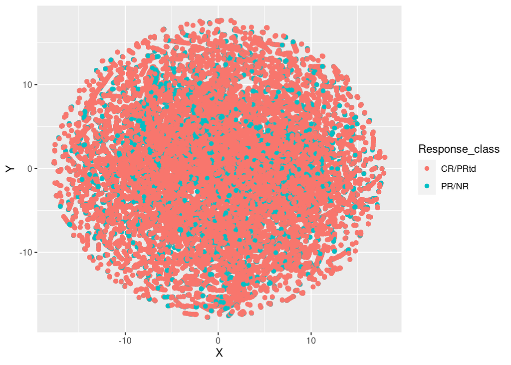

```r
ggplot(df, aes(x=X, y=Y, color=Response_class)) +
  geom_point()
```

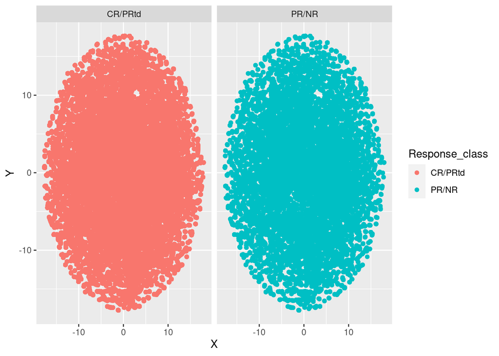

```r
ggplot(df, aes(x=X, y=Y, color=Response_class)) +
  geom_point() +
  facet_wrap( ~ Response_class)
```

Formatting projection and responce of each site

```r
pyx <- df %>% select(c(X,Y))
pyy <- df %>% select(Response_class)
```

# 3 Running python code

The **“r”** object **python** contains an interface to the **R** variables

```python
import pandas
from sklearn.neighbors import RadiusNeighborsClassifier

model = RadiusNeighborsClassifier(radius=0.1)
__ = model.fit(r.pyx,r.pyy.values.ravel())
yhat = model.predict(r.pyx)
```

The **“py”** object in **R** contains an interface to the **python** variables

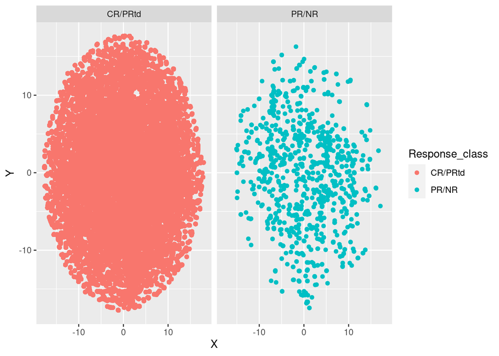

```r
df_imp1 <- df[py$yhat == df$Response_class,]

 ggplot(df_imp1, aes(x=X, y=Y,color=Response_class)) +
 geom_point() +
 facet_wrap( ~ Response_class)
```

More information can be found in https://rstudio.github.io/reticulate/